# Facial emotion recognition in children with ADHD Pre-registration

Adapted from https://osf.io/preprints/metaarxiv/epgjd into markdown format.

- Study Information
  - 1. Title
  - 2. Authors
  - 3. Description
  - 4. Hypotheses
- Design Plan
  - 5. Study type experimental
  - 6. Blinding
  - 7. Is there any additional blinding in this study?
  - 8. Study design
  - 9. Randomization
- Sampling Plan
  - 10. Existing data
  - 11. Explanation of existing data
  - 12. Data collection procedures
  - 13. Sample size
  - 14. Sample size rationale
  - 15. Stopping rule
- Variables
  - 16. Manipulated variables
  - 17. Measured variables
  - 18. Indices
- Analysis Plan
  - 19. Statistical models
  - 20. Transformations
  - 21. Inference criteria
  - 22. Data exclusion
  - 23. Missing data
  - 24. Exploratory analysis

# Study Information

## 1. Title

Gender differences in facial emotion recognition impairment in subthreshold and full syndrome ADHD.

## 2. Authors

Asha Djianto

## 3. Description

Attention Deficit Hyperactivity/Impulsivity Disorder (ADHD) is a neurodevelopmental disorder characterized by inattention, hyperactivity and/or impulsivity (American Psychiatric Association, 2013). Previous research shows impairment of Facial Emotion Recognition (FER) in ADHD, which impacts daily social interactions and feelings of social incompetence (Bunford et al., 2018, Tehrani-Doost et al., 2017, Staff et al., 2022). This leads to psychological disorders such as depression and anxiety that are commonly comorbid with ADHD diagnoses (Cho et al., 2009).

The level of FER impairment differs between different facial expressions (Boakes et al., 2007). Staff et al. (2022) found that the difference in FER impairment between the ADHD and control group was small for happy and sad expressions (d = ~ .2), while the effect size was moderate for expressions of fear and anger (d = ~ .5). Recognition of different facial expressions are processed through different areas of the brain. For example, Boakes et al. (2007) mentions disgust to be processed in the basal ganglia. Their study also found that the ADHD group presented significant impairments in FER of disgust and fear which fit their models of irregularities in the basal ganglia in ADHD. This highlights the importance of testing all basic emotions when studying FER in ADHD.

Most research on FER looks at explicit FER, which involves labelling emotions (Boakes et al., 2007, Berggren et al., 2016, Staff et al., 2022), but much of real-world FER is implicit and dependent on context. Implicit FER was tested by presenting either an image of a scene with the target face blocked out (Fonesca et al., 2009) or reading out a scenario (Yuill & Lyon, 2007) to provide the context in which the target face would be expressed in. Instead of explicitly labelling, participants were to select from emoticons which facial expression best represents the target face on the presented/read-out scene. As a control trial, both studies used non-emotional situations and images that required selecting objects as opposed to emoticons. These studies found similar results to the explicit FER studies, but found greater variation in the ADHD group’s FER accuracy which led to insignificant interaction effects between group (ADHD vs. TD) and condition (emotional vs. non-emotional). This demonstrates the importance of including more naturalistic, implicit FER tests to assess FER impairment in ADHD groups.

The DSM-5 diagnostic criteria requires at least 6 symptoms of inattention and/or of hyperactivity/impulsivity (American Psychiatric Association, 2013), but there is strong evidence that the diagnostic criteria for ADHD is heavily biased toward boys due to girls internalizing behaviour more than boys (Goerz, 2023). This leads to an under diagnosis of ADHD in girls and so they don’t get the treatment that they need or being diagnosed with psychological or learning disabilities. Hong et al. (2014) found that children with subthreshold ADHD experienced similar impairments to full syndrome ADHD. They also suggested that subthreshold ADHD may be a more accurate measure for ADHD in girls. The purpose of the current study is to look into possible gender differences in children with ADHD to obtain information on more sensitive measures of ADHD in girls. Boys and girls experience different psychosocial problems as children; boys tend to be more aggressive while girls tend to be more sensitive to negative events (Rucklidge, 2008). This demonstrates the different emotions that boys and girls experience most often. Taking all this together, the current study will test boys and girls of differing ADHD levels on their FER ability for different emotion types. Understanding which emotion is more impaired in FER can inform diagnostic criteria as well as focus for treatment interventions.

## 4. Hypotheses

In the ADHD group, if there is a main effect of gender on FER reaction time, then the boys’ average reaction time (RT) will be significantly faster than the girls’ (directional).

In the ADHD group, if gender and emotion type are dependent on each other, then girls will be faster than boys at recognizing sad faces and boys will be faster than girls at recognizing angry faces.

# Design Plan

## 5. Study type

**Mixed Factorial Design** - A within-subjects factor that all participants will engage in across two different groups. **Quasi-Experimental Design** - Participants are assigned to groups with a non-randomized method.

## 6. Blinding

> Mark all that apply.
- No blinding is involved in this study.
- For studies that involve human subjects, they will not know the treatment group to which they have been assigned.
- Personnel who interact directly with the study subjects (either human or non-human subjects) will not be aware of the assigned treatments. (Commonly known as “double blind”)
- Personnel who analyze the data collected from the study are not aware of the treatment applied to any given group.

## 7. Is there any additional blinding in this study?

There will be no additional blinding in this study as all participants in all groups will be completing all emotion trials in this study.

## 8. Study design

This study is a mixed factorial design that includes 2 factors. The between group factor is gender (boys, girls). The within-subjects factor is the emotion type, where all participants will be tested on 3 different emotion types: happy, sad, and angry.

The entire study is a web-based experiment. The study will start off with a FER test. This involves participants looking at an image of a scene at the centre of the screen with the target face blocked out with a white circle (figure 1a). The target face will show one of the 3 emotion types based on the context of the scene. The stimuli will be on the screen for 750 ms before changing to the response screen. The response screen will show all 3 possible emotions as emoticons (figure 1b) and the participant must press the emoticon they feel best represents the target face. The response section is self-paced and reaction time (RT) will be recorded to measure efficiency of processing. There will be 24 trials total with each emotion showing up 8 times in a randomized order.

Figure 1

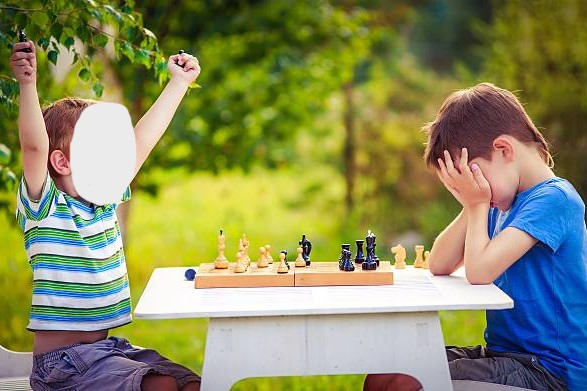

Example of test stimuli.

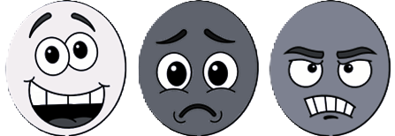

Note. Emoticons representing the 3 basic emotions to be used in the current study. From left to right; happy, sad, and angry.

After the FER test, the participants will be brought to a survey to measure their ADHD symptoms. This survey will be how participants are assigned to the different ADHD symptom level groups. There will be statements that align to each ADHD symptom in the DSM-5 diagnostic criteria with forced choice options (agree, disagree). If they agree to 6 or more of the statements, they will be a part of the ADHD group. If they agree to 3–5 statements, they are a part of the subthreshold group. Less than 3 would be a part of the typically developing (TD) group. These group assignments will be used in the analyses of the results except the TD group which will only be used for exploratory analysis.

## 9. Randomization

Group assignment will not be randomized due to the study being within-subject in nature, but order of trial presentation will be randomized. This means that the order in which the different emotion types (happy, sad, angry) are presented will be completely randomized for each participant.

# Sampling Plan

## 10. Existing data

> Preregistration is designed to make clear the distinction between confirmatory tests, specified prior to seeing the data, and exploratory analyses conducted after observing the data. Therefore, creating a research plan in which existing data will be used presents unique challenges. Please select the description that best describes your situation. Please do not hesitate to contact us if you have questions about how to answer this question (prereg@cos.io).
- Registration prior to creation of data: As of the date of submission of this research plan for preregistration, the data have not yet been collected, created, or realized.
- Registration prior to any human observation of the data: As of the date of submission, the data exist but have not yet been quantified, constructed, observed, or reported by anyone - including individuals that are not associated with the proposed study. Examples include museum specimens that have not been measured and data that have been collected by non-human collectors and are inaccessible.
- Registration prior to accessing the data: As of the date of submission, the data exist, but have not been accessed by you or your collaborators. Commonly, this includes data that has been collected by another researcher or institution.
- Registration prior to analysis of the data: As of the date of submission, the data exist and you have accessed it, though no analysis has been conducted related to the research plan (including calculation of summary statistics). A common situation for this scenario when a large dataset exists that is used for many different studies over time, or when a data set is randomly split into a sample for exploratory analyses, and the other section of data is reserved for later confirmatory data analysis.
- Registration following analysis of the data: As of the date of submission, you have accessed and analyzed some of the data relevant to the research plan. This includes preliminary analysis of variables, calculation of descriptive statistics, and observation of data distributions. Please see cos.io/prereg for more information.

## 11. Explanation of existing data

No existing data will be used in this study.

## 12. Data collection procedures

Participants will be recruited through elementary public schools (ages 7–13) across Canada. School districts across Canada will be emailed to ask for participation in the current study. The email will include the study information as well as a sample of the web-based experiment. Consenting school districts will be provided an email to send to elementary schools informing them of the experiment and given options and timelines in which the study can be delivered to their students. Classroom teachers will be given a consent form for students’ parents to sign for them to be able to participate in the web-based experiment. A part of the consent form will include a section to specify whether the child is taking any ADHD medication in which if they are, their results will be excluded from the analysis. Non-consenting parties will also be excluded from the experiment. Consenting parties will complete the experiment during a scheduled class time on the school’s computers (eg., in a computer lab). The recruitment phase (distributing consent forms) will be done during the first term of the school year, and the experiment’s data collection will be done over the span of following school term. Participating schools will be given pencils and stickers to distribute to students for participating.

## 13. Sample size

The target sample size per gender and ADHD symptom level group is 27. We will attempt to recruit 40 per group assuming that not all will complete the total task (girls:ADHD, girls:subthreshold, girls:TD, boys:ADHD, boys:subthreshold, boys:TD = 240 total).

## 14. Sample size rationale

A power analysis using RStudio was conducted to determine the sample size per group. The variables were a significance level of 0.05, 80% power, standard deviation of 1, and an expected medium effect size (d = 0.5) between groups.

## 15. Stopping rule

Recruitment for data collection will stop being collected once the target sample size is met for each group (40 per group). Because ADHD symptom level groups are expected to be unequal within a population, for the analysis portion of the study, a stratified randomization technique will be used to select 30 participants per group where the selection of participants within each group will be completely randomized. This is to allow for as unbiased analysis as possible by creating equal sample sizes for each group.

# Variables

## 16. Manipulated variables

The emotion type presented in each scene is the manipulated variable. The 3 categories of this variable are ‘happy’, ‘sad’, and ‘angry’. The images used for each emotion type will be verified by adult participants to ensure consensus on the emotion of the target face in each image.

## 17. Measured variables

The measured variable will be reaction time (RT in ms) to test the efficiency of different group’s FER strategy for correctly matched trials. The RT will be measured from the start of the response screen to when the participant clicks on one of the response emoticons.

Proportion correct (number of correctly matched trials / total number of trials) will also be calculated for further exploratory analyses.

The ADHD survey after the FER test will measure the number of ADHD symptoms the participant has based on self-report measures. This will be used to assign each participant in their respective ADHD symptoms level groups.

## 18. Indices

Group RT and proportion correct will be combined into means to allow for analyses between group means.

ADHD symptoms will be measured using survey questions based on the DSM-5 diagnostic criteria for ADHD. In the ADHD survey, each statement is taken from the DSM-5 and the possible responses are forced choice options (agree/disagree). Every response to the statements on the inattention survey that corresponds with ADHD will count as 1 symptom of inattention. Every response to the statements on the hyperactivity/impulsivity survey that corresponds with ADHD will count as 1 symptom of hyperactivity/impulsivity. 0–2 symptoms of inattention and/or hyperactivity/impulsivity will represent the TD group, 3–5 symptoms of inattention and/or hyperactivity/impulsivity will represent the ST group, and 6+ symptoms of inattention and/or hyperactivity/impulsivity will represent the ADHD group.

# Analysis Plan

## 19. Statistical models

To test the interaction effect hypothesis, I will use a 2x3 factorial ANOVA to see if the effect of emotion type on RT is dependent on gender in the full syndrome ADHD group. The pairwise comparisons will be comparing each emotion-gender group with each other (e.g., happy:girl–happy:boy, happy:girl–sad:boy, sad:girl–happy:boy, etc.). There are a total of 15 possible comparisons, but only relevant comparisons will be done depending on whether there is a main effect of emotion type and/or a main effect of gender.

For the subthreshold group, the same calculations as the 2x3 factorial ANOVA described above will be used.

A post-hoc test, Tukey-Kramer test will be used for all pairwise comparisons to adjust for multiple comparisons and to see where significant differences exist if applicable.

Eta-squared will be used to calculate effect size and partial eta-squared will be used to isolate the proportion of variance from each main and interaction effect.

## 20. Transformations

Some questions on the ADHD survey will be reversed scored, so instead of only counting ‘agree’ responses as a symptom of ADHD, some questions will count as a symptom of ADHD when they respond ‘disagree’. For example, if a participant disagreed with the statement “most of the time, I am able to wait my turn to speak in a conversation,” then that would count as a symptom of ADHD in the current study’s survey.

## 21. Inference criteria

This study will use the standard p<0.05 criteria for determining significant differences for all ANOVA and post-hoc tests.

## 22. Data exclusion

Participant data will be excluded if one or more questions on the ADHD survey is not responded to, if RT for a trial was greater than 3 SDs above the child’s mean (Staff et al., 2022), and if the parent/guardian indicates that the child is taking ADHD medication within 24hrs of participating in the study.

## 23. Missing data

If a participant does not answer one or more questions in the ADHD survey at the end of the study, they will not be included in the analysis since answers to all questions are required for group assignment.

## 24. Exploratory analysis

Considering that Hong et al. (2014) suggests that the diagnostic criteria for subthreshold ADHD may be more sensitive for girls, I will explore whether there are any significant differences in RT between girls with subthreshold ADHD and full syndrome ADHD. This will also be compared to the pairwise comparison of boys with subthreshold ADHD and full syndrome ADHD.

To test if there is a difference in FER RT based on ADHD symptom level between the genders, a paired samples t-test will compare the subthreshold and full syndrome ADHD girls on their average RT across all emotion types. The same pairwise comparison will be done for subthreshold and full syndrome ADHD boys to compare significance results.

# References

American Psychiatric Association. (2013). Diagnostic and statistical manual of mental disorders: DSM-5. American psychiatric association.

Berggren, S., Engström, A. C., & Bölte, S. (2016). Facial affect recognition in autism, ADHD and typical development. Cognitive Neuropsychiatry, 21(3), 213–227.

Boakes, J., Chapman, E., Houghton, S., & West, J. (2007). Facial affect interpretation in boys with attention deficit/hyperactivity disorder. Child Neuropsychology, 14(1), 82-96.

Bunford, N., Evans, S. W., & Langberg, J. M. (2018). Emotion dysregulation is associated with social impairment among young adolescents with ADHD. Journal of attention disorders, 22(1), 66-82.

Cho, S. C., Kim, B. N., Kim, J. W., Rohde, L. A., Hwang, J. W., Chungh, D. S., … & Kim, H. W. (2009). Full syndrome and subthreshold attention-deficit/hyperactivity disorder in a Korean community sample: comorbidity and temperament findings. European child & adolescent psychiatry, 18, 447-457.

Da Fonseca, D., Seguier, V., Santos, A., Poinso, F., & Deruelle, C. (2009). Emotion understanding in children with ADHD. Child psychiatry and human development, 40, 111-121.

Goerz, A. (2023). Gender Bias in Diagnosing and Treating ADHD. Gender: Reflections and Intersections.

Hong, S. B., Dwyer, D., Kim, J. W., Park, E. J., Shin, M. S., Kim, B. N., & Cho, S. C. (2014). Subthreshold ADHD is associated with functional impairment across domains: A comprehensive analysis in a large-scale community study. European Child & Adolescent Psychiatry, 23, 627-636.

Rucklidge, J. J. (2008). Gender differences in ADHD: implications for psychosocial treatments. Expert Review of Neurotherapeutics, 8(4), 643-655.

Staff, A. I., Luman, M., Van der Oord, S., Bergwerff, C. E., van den Hoofdakker, B. J., & Oosterlaan, J. (2022). Facial emotion recognition impairment predicts social and emotional problems in children with (subthreshold) ADHD. European Child & Adolescent Psychiatry, 1-13.

Tehrani-Doost, M., Noorazar, G., Shahrivar, Z., Banaraki, A. K., Beigi, P. F., & Noorian, N. (2017). Is Emotion Recognition Related to Core Symptoms of Childhood ADHD?. Journal of the Canadian Academy of Child and Adolescent Psychiatry = Journal de l’Academie canadienne de psychiatrie de l’enfant et de l’adolescent, 26(1), 31–38.

Yuill, N., & Lyon, J. (2007). Selective difficulty in recognising facial expressions of emotion in boys with ADHD: general performance impairments or specific problems in social cognition?. European child & adolescent psychiatry, 16, 398-404.